# INTRODUCTION TO R PROGRAMMING

Boise State University

DATA-R155, BIOL155, PSYC155, SOC155, ANTH580

# Lesson 12

by Lorraine Gaudio

Lesson generated on November 10, 2025

# 1 🎲 Welcome Back to R!

We shift ⚙️gears from the `dyplr` functions to using R’s built‑in tools to visualize simuations. Simulation lets you create synthetic data, test ideas quickly, and understand probability without a math degree. We will learn three key functions: `sample()`, `rnorm()`, and `replicate()`. While we are at it, we’ll learn how to use base R to visualize the results using `hist()`.

📦 No extra packages are needed today. We’ll be using built-in stats functions.

To begin Lesson 12, follow these steps:

1. Open your course project for RStudio
2. Create a new file. From the file types we have used so far, pick which file type you want to use. (File > New File > ???).
3. Type in the code provided in this document as you follow along with the video. Pause the video at anytime to answer assignment questions, dig deeper or add memo notes. In the same file, complete the assignment at the end of this document. Use memos in your assignment portion to explain your thinking.

**Lesson Overview**

By the end of Lesson 12 you will be able to:

1. ⚡ Remember – Name `sample()`, `rnorm()`, and `replicate()`.
2. 🔍 Understand – Explain when to use replacement and probability weights in `sample()`.
3. 🛠 Apply – Simulate coins, dice, and normal data with code
4. 📊 Analyze – Visualize simulated results with `hist()` and interpret shapes.
5. 🧠️ Evaluate –Judge whether simulated outcomes match an expected distribution (fair vs. biased).

Keep these goals in mind as you move through each section.

# 2 Distribution of Sums

🎯 Identify the “Shape of Data” (or “Distribution of data”) is *optional reading*, but may help you answer questions in this lesson.

1. **Uniform**: All bars have approximately the same height, indicating that all values are equally likely.

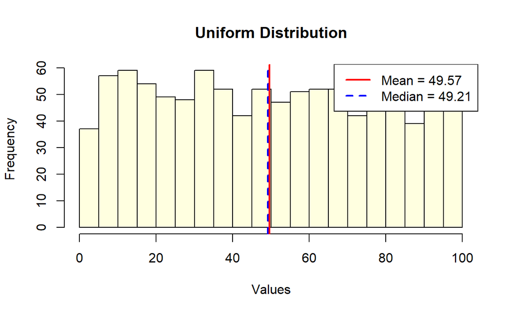

2. **Symmetric**: This bell-shaped (normal) distribution is the left and right sides of the histogram are nearly mirror images of each other. Mean and median are approximately equal. $Median \approx Mean$.

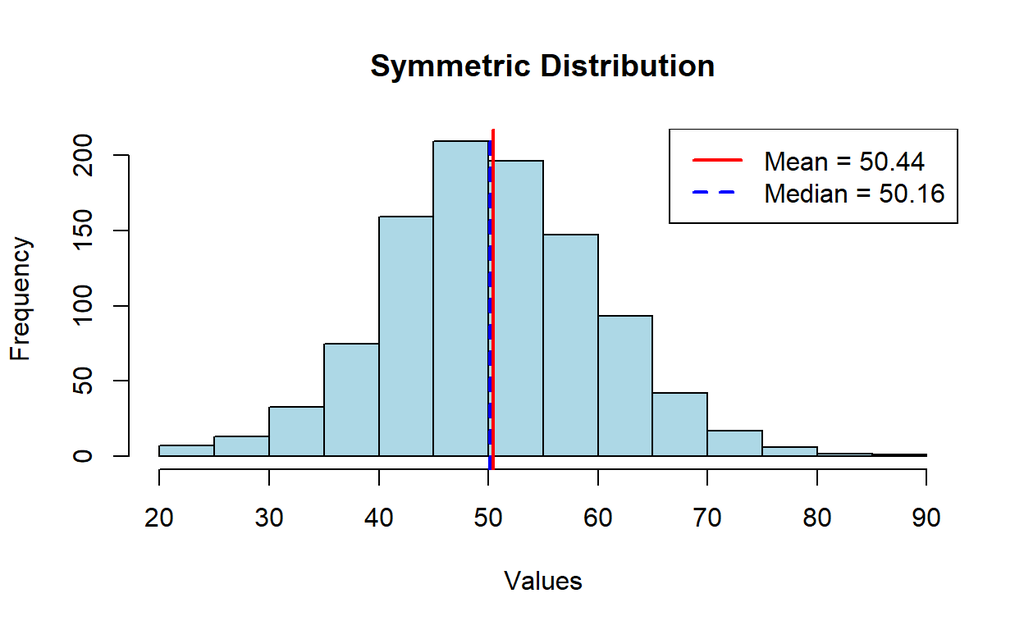

3. **Skewed Right**: The right *tail* is longer than the left tail, indicating that there are a few high values that pull the mean to the right. *Positive skewness*. The mean is more right than the median due to extreme values. $Median < Mean$.

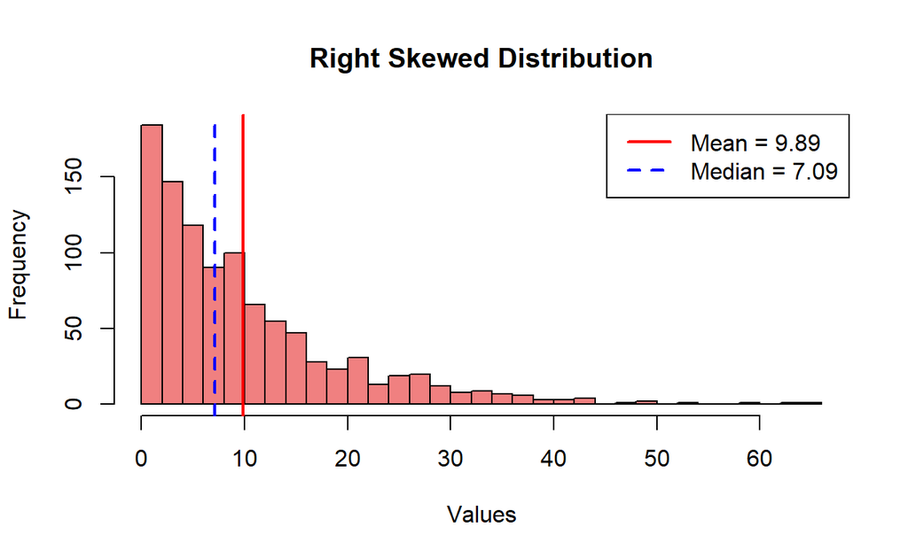

4. **Skewed Left**: The left *tail* is longer than the right tail, indicating that there are a few low values that pull the mean to the left. *Negative skewness*. $Median > Mean$.

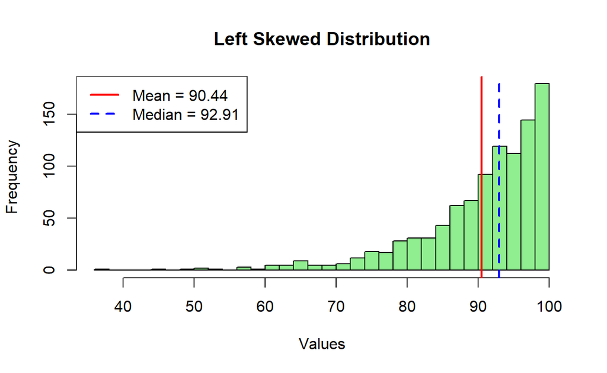

5. Bimodal (Split Distribution): The distribution has two distinct peaks or modes. This suggests that the data might come from two different groups or processes. The mean and median may fall between the peaks, providing misleading summary statistics. Bimodal distributions often indicate hidden subpopulations.

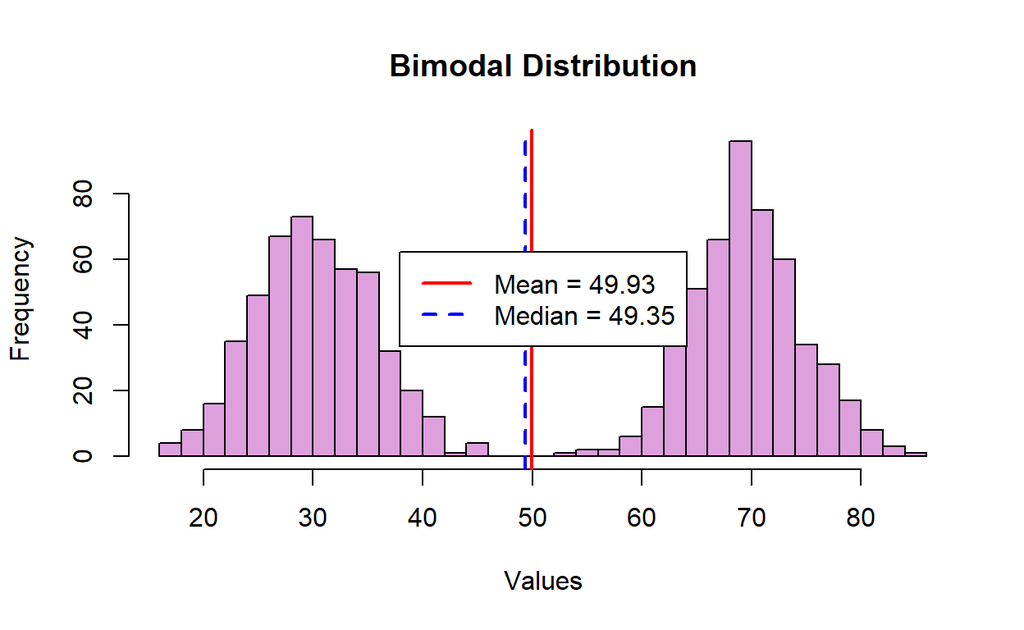

# 3 Warm‑Up

A data analyst uses `set.seed()` to ensure that random processes like sampling or simulation produce the same results each time the code is run (from top to bottom). This reproducibility is crucial for debugging, collaboration, and verifying results, as it guarantees consistency across analyses and users.

```r
# ⚡ Test
set.seed(2025)  # 🎯 for reproducibility
```

*If you re-run code more than once within your document, your values will not be the same. It is only the same when you run the code from top to bottom in one session.*

# 4 Simulating

## 4.1 🪙 Coin Flips

🎯 The GOAL: Flip 💰 1,000 fair coins (0 = heads, 1 = tails) and count tails.

Terminology: **Sample Space**: “$S$” A collection (or set) of all possible outcomes in a random experiment.

Set Notation: $S$ = {Head, Tail}

1. 🎯 Create the data through a simulation

```r
# ⚡ Test
# sample(x, size, replace = FALSE, prob = NULL)
coins <- sample(x = 0:1, size = 1000, replace = TRUE)
```

🗣 Comment (example):`x = 0:1` means that we are sampling from either 0 or 1. As the researcher, I decide that 0 = heads and 1 = tails. We set `size = 1000` to flip the coin 1,000 times. We set `replace = TRUE` because we “put the coin back” each flip.

```r
# ✅  Verify
unique(coins)   # values in our data set
length(coins) # total number of flips
typeof(coins)  # type of object
```

🗣 Comment (example): Coins contains 0 and 1 values where 1 represents tails of a coin flip. There are 1000 values in the integer vector.

💬 Prediction: How many tails are in our data set?

🎯 Use sum to count the number of tails because 1 = tails

```r
# ⚡ Test
sum(coins)
```

🗣 Comment (your turn): How many tails are in our data set? Why does `sum(coins)` count the tails?

🚀 Explore and Play: Can you make a new data set where heads = 1? Try `1 - coins` and sum. Why would this work?

🛠 Break Things! What happens if `replace = FALSE` keeping `size = 1000`? Memo: paste the error message and 1 sentence on why it occurs.

## 4.2 🎲 Dice Rolls

🎯 The GOAL: Simulate 10,000 rolls of a fair 6‑sided die and plot the results.

Set Notation: $S$ = {1, 2, 3, 4, 5, 6}

💬 Prediction: How many times do you expect each face to appear? Will the values be exactly equal? Have a normal distribution? Something else? Type your answer before working ahead. *Keep whatever you typed, even if you are wrong. That’s the integrity of science!*

```r
# ⚡ Test
dice <- sample(1:6, 10000, replace = TRUE)
```

To investigate our hypothesis, we’ll visualize the results with a histogram using base R.

# 5 📊 Histograms

🎯 Use `hist()` to create a histogram of the dice rolls, showing the frequency of each face value.

```r
?hist
```

📜 The SYNTAX: `hist(x, breaks, col, main, xlab, ylab)`

- `x` is the data to plot
- `breaks` controls the number of bins (or bars)
- `col` sets the color of the bars
- `main` is the title of the plot
- `xlab` and `ylab` label the x- and y-axes

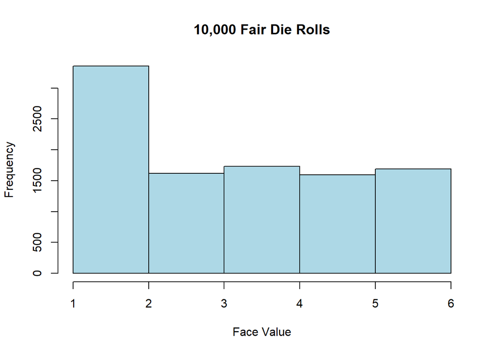

```r
# ✅  Verify
hist(dice,                  # The data to plot
     breaks = 6,
     col    = "lightblue",  # Color of the bars
     main   = "10,000 Fair Die Rolls", # Title of the plot
     xlab   = "Face Value") # Label for the x-axis
```

🗣 Comment (example): The y-axis label is automatically set to “Frequency” by default.

🧐 NOTICE: Bars should be roughly equal height, forming a uniform distribution. That isn’t what we see.

When we specify breaks = 6, base R doesn’t create bins that align perfectly with our integer values 1-6. The bins slice the integers unevenly, leading to misleading bar heights.

🎯 The GOAL: Fix the breaks to align with die face values.

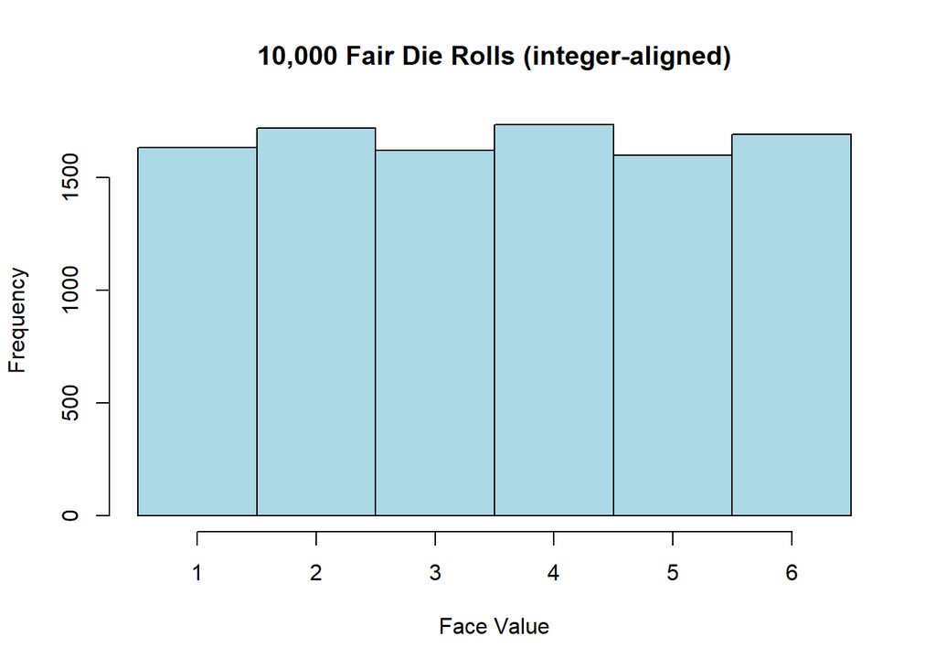

```r
# ⚡ Test
hist(dice,
     breaks = seq(0.5, 6.5, by = 1),  # centers bars on 1:6
     col    = "lightblue",
     main   = "10,000 Fair Die Rolls (integer-aligned)",
     xlab   = "Face Value")
```

🗣 Comment (example): The bars look more even now.

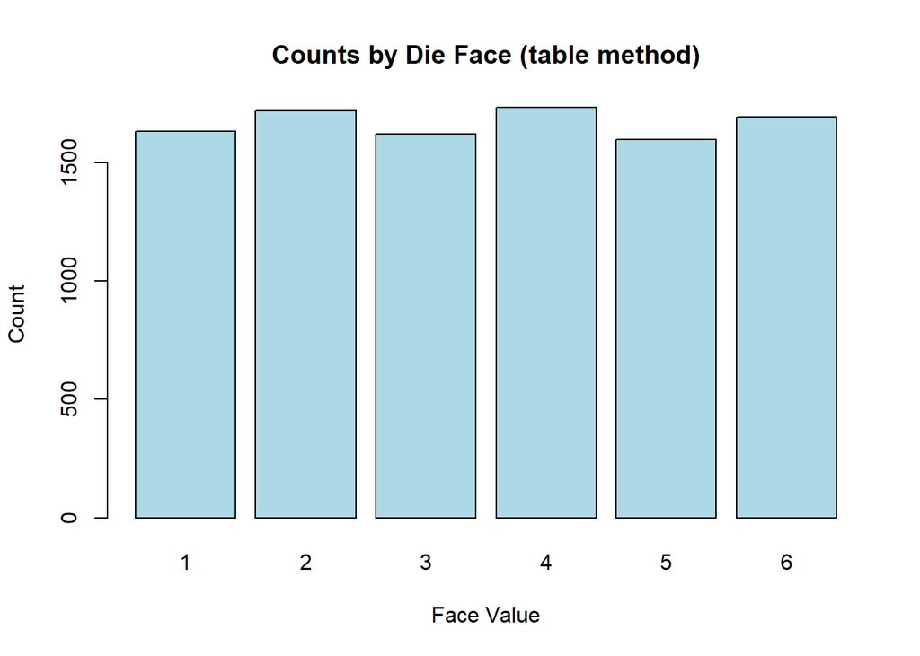

```r
# Alternative display for discrete data
barplot(table(dice),
        main = "Counts by Die Face (table method)",
        col    = "lightblue",
        xlab = "Face Value",
        ylab = "Count")
```

🗣 Comment (example): The table() function provides an alternative way to display the data accurately.

# 6 🎲🎲 Two Dice

💬 Prediction: What histogram shape do you expect when summing the face value of two dice? Will the values be exactly equal? Have a normal distribution? Something else? Type your answer before working ahead. *Keep whatever you typed, even if you are wrong.*

🎯 The GOAL: Roll two dice 10,000 times, add the results, plot.

```r
# ⚡ Test
sum_two <- sample(1:6, 10000, TRUE) + sample(1:6, 10000, TRUE)

# ✅  Investigate
hist(sum_two,
     breaks = seq(1.5, 12.5, by = 1),  # Creates bins centered on integers 2-12
     col    = "salmon",
     main   = "Sum of Two Dice (10,000 trials)",
     xlab   = "Total")
```

[output not shown]

🚀 Explore and Play: We used the column “salmon” to create the figure. Test out other `col` options. Which are your favorite?

```r
colors()  # Lists all color names in R
```

# 7 ☯️ Symmetric Data

The functions `rnorm()` generates a vector of random numbers that form a normal (bell-shaped) distribution.

```r
?rnorm  # Check the help file for rnorm()
```

📜 The SYNTAX: `rnorm(n, mean = 0, sd = 1)`

- `n` is the number of random numbers to generate.
- `mean` is the average value of the distribution.
- `sd` is the standard deviation, controlling the spread of the distribution.

🎯 The GOAL: Simulate 1,000 adult female heights ~ $N(64, 2.5^2)$ and inspect.

```r
# ⚡ Test
heights <- rnorm(n = 1000, mean = 64, sd = 2.5)
```

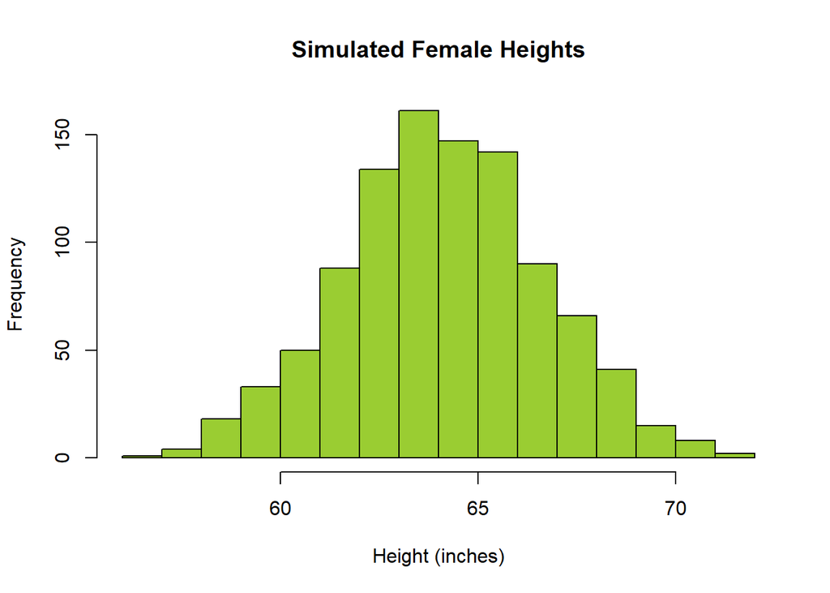

```r
# ✅  Verify
hist(heights,
     col    = "yellowgreen",
     main   = "Simulated Female Heights",
     xlab   = "Height (inches)")
```

The `breaks =` are unnecessary here because `hist()` automatically chooses appropriate bins for continuous data.

```r
# ✅  Verify
"Mean = "
```

```
## [1] "Mean = "
```

```r
mean(heights)
```

```
## [1] 64.11653
```

```r
"SD = "
```

```
## [1] "SD = "
```

```r
sd(heights)
```

```
## [1] 2.508912
```

🗣 Comment (example): The histogram shows a bell-shaped distribution of heights, centered around the mean of 64 inches. The spread of the data is consistent with the specified standard deviation of 2.5 inches.

Sample vs. Population Parameters: You might wonder, “Why aren’t the sample mean and standard deviation exactly 64 and 2.5?” This is because these are random samples from a normal distribution with those parameters. Each time we run the simulation, we get slightly different values due to sampling variability.

In summary, the function `rnorm()` generates random numbers from a normal distribution and is used for modeling normally distributed data using the parameters: number of values, mean, and standard deviation. This will only generate symmetric data.

# 8 🔁 Repeating a Simulation

The function `replicate()` repeats an expression multiple times and collects the results. This control structure is like a loop is used to repeat sample estimate probabilities (simulations), resample data to estimate variability or confidence intervals (bootstrapping), model repeated trials of an experiment, generate synthetic data and more. This function is flexible as it can wrap any code, not just random generation.

That said, Monte Carlo simulations are the classic use case for `replicate()`. These simulations model are used to understand and manage risk and uncertainty using probabilities.

```r
?replicate  # Check the help file for replicate()
```

📜 The SYNTAX: `replicate(n, expr, simplify = "array")`

- `n` is the number of replications.
- `expr` is the expression (a language object, usually a call) to evaluate repeatedly.
- `simplify` indicates whether the result should be simplified to a vector, matrix or array if possible. The default is `"array"`.

🎯 The GOAL: How variable is the number of tails in 5,000 flips? Repeat 100 times.

💰💰💰 …. 💰 That’s a lot of coins tosses!

```r
# ⚡ Test
tails_100 <- replicate(n = 100, expr = sum(sample(0:1, 5000, TRUE)))
```

The `replicate()` function:

1. Evaluates the entire expression 100 times (because `n = 100`)
2. Each evaluation is independent (gets its own random sampling)
3. Store the 100 results in a vector called `tails_100`

```r
# ✅  Verify
summary(tails_100)
```

```
##    Min. 1st Qu.  Median    Mean 3rd Qu.    Max.
##    2412    2477    2499    2502    2525    2582
```

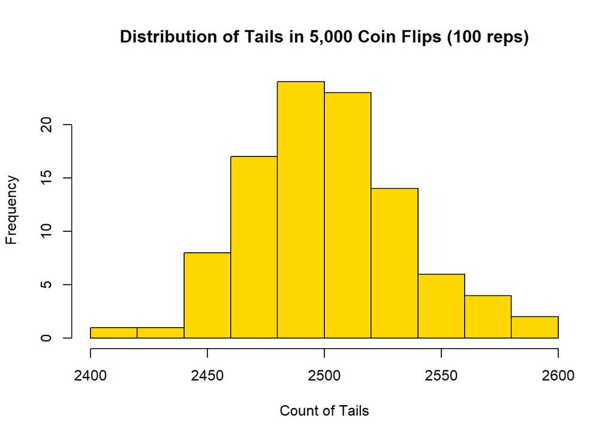

```r
# ✅  Verify
hist(tails_100,
     col    = "gold",
     main   = "Distribution of Tails in 5,000 Coin Flips (100 reps)",
     xlab   = "Count of Tails")
```

🗣 Comment (example): The spread shows sampling variability around the theoretical 2,500.

## 8.1 Normal Data with `replicate()`

💭 Scenario. Pretend that the university is considering making specifications grading standard practice. The provost’s office says that if thirty percent or more of students oppose this, it would trigger a halt to the proposal. We want to know the risk of the proposal being halted.

We run a survey where student attitudes are measured on a continuous scale:

- 0 = neutral,
- negative values = oppose,
- positive values = support.

We’ll first run a random-sample survey of 50 students. Then we simulate many 50-student samples to see how much the number of opponents could vary. That variability informs the proposal planning.

### 8.1.1 Opinion Study

🎯 The GOAL: Generate 50 random numbers, compare each to zero, and count how many are below zero.

```r
set.seed(1234)  # For reproducibility
# Generate 50 random numbers to represent student attitudes from survey
# with a normal distribution (mean = 2, sd = 3)
x <- rnorm(n = 50, mean = 2, sd = 3)
print(x)
```

🗣 Comment (example): While the average opinion is supportive (mean = 2), some individuals express opposition (negative values). In other words, some values are below zero because the mean is 2, but the standard deviation is 3, allowing for negative values. That’s normal sample-to-sample variation.

```r
# Mark who opposes (score < 0), then count
below_zero <- x < 0
print(below_zero)

# Count how many are below zero
count <- sum(below_zero)
print(count)
```

🗣 Comment (example): We generated 50 random numbers from a normal distribution with mean 2 and standard deviation 3. We then compared each number to zero, yielding a logical vector indicating which are below zero. Finally, we summed the logical vector to count the number of values below zero.

### 8.1.2 Simulation Over Many Samples

Now simulate many realistic samples to understand how the count of opponents might bounce around.

Repeat this process multiple times using `replicate()`. This time, let’s generate 50 random numbers in 200 iterations.

🎯 The GOAL: Use `replicate` to repeat the counts across many simulated samples.

```r
# ⚡ Test
values_below_zero <- replicate(
  n = 200,                                     # 200 hypothetical survey runs
  expr = sum(rnorm(50, mean = 2, sd = 3) < 0)) # each run: 50 students, count opponents
```

Order of Operations:

1. `rnorm(n = 50, mean = 2, sd = 3)` generates a sample of 50 random numbers.
2. `sum(... < 0)` counts how many of those numbers are below zero.
3. `replicate(n = 200, expr = ...)` repeats this process 200 times.
4. The result is a vector of counts, one for each of the 200 samples.

```r
# ✅  Investigate
# Useful summaries for discussion
mean(values_below_zero)   # typical number of opponents
```

```
## [1] 12.77
```

```r
sd(values_below_zero)     # how much the count varies
```

```
## [1] 3.121831
```

```r
quantile(values_below_zero, c(.1,.5,.9))  # 10th/50th/90th percentiles
```

```
## 10% 50% 90%
##   9  13  17
```

🗣 Comment (example): The mean indicates that, on average, the typical count of those opposed is about 13 across many samples of 50 students. The standard deviation shows that the count of opponents can vary by about 3.1 from sample to sample. The percentiles provide additional insights into the distribution of opponent counts, indicating that in 10% of the samples, there are 9 or fewer opponents, while in 90% of the samples, there are 17 or fewer opponents.

```r
# Example planning thresholds (adjust to your context)
mean(values_below_zero >= 15)  # How often do we see ≥15 opponents out of 50?
```

```
## [1] 0.28
```

If at least 15 opponents trigger a halt, the proposal’s risk of being halted is about 28% based on our simulations.

```r
# Alternative way to calculate probability of halt
# One-line simulation estimate:
risk_halt <- mean(replicate(200, sum(rnorm(50, 2, 3) < 0)) >= 15)
risk_halt
```

```
## [1] 0.2
```

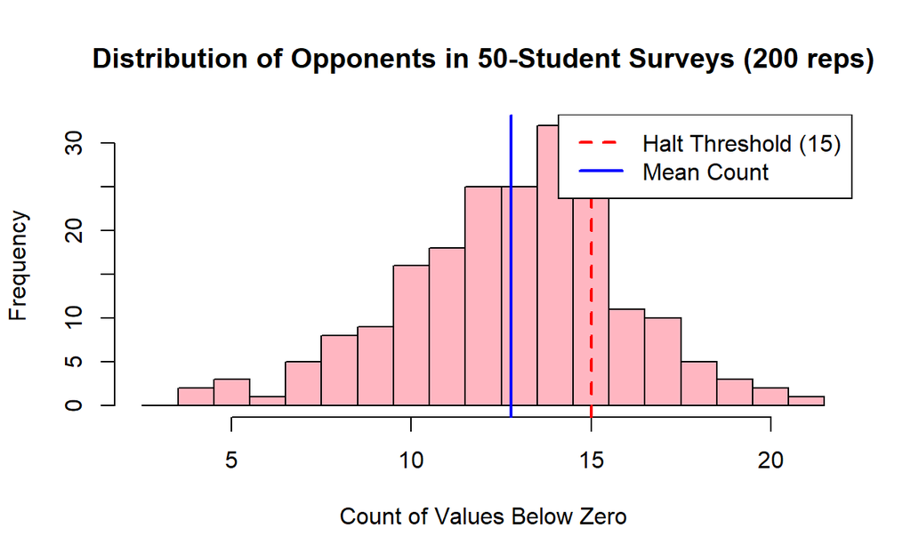

```r
# Integer-aligned histogram + shading + on-plot probability
threshold <- 15
max_count <- max(values_below_zero)
breaks_int <- seq(2.5, max_count + 0.5, by = 1)

# ✅  Investigate
hist(values_below_zero,
     breaks = breaks_int,
     col    = "lightpink",
     main   = "Distribution of Opponents in 50-Student Surveys (200 reps)",
     xlab   = "Count of Values Below Zero")


abline(v = threshold, col = "red", lwd = 2, lty = 2) # Halt threshold
abline(v = mean(values_below_zero), col = "blue", lwd = 2, lty = 1)  # Mean line

legend("topright",
       legend = c("Halt Threshold (15)", "Mean Count"),
       col = c("red", "blue"),
       lty = c(2, 1),
       lwd = 2,
       bg = "white",
       bty = "o")
```

🗣 Comment (example): Each bar shows how often a particular count of opponents appeared across the 200 samples. The center of the histogram is the typical count. The spread shows how much that count changes from sample to sample, even if the underlying social climate doesn’t change. About 1 in 4 samples hit the halt threshold (≥15).

# 9 ⚖️ Fair-Dice Check

Probability weights in `sample()` let you simulate biased outcomes. Recall the syntax:

📜 The SYNTAX: `sample(x, size, replace = FALSE, prob = NULL)`

## 9.1 Biased Die

The `prob` parameter specifies the probability weights for each element in the sampling pool.

🎯 The GOAL: Simulate rolling a biased die 1,000 times with specified probabilities.

```r
# ⚡ Test
rolls <- sample(1:6, 1000, prob = c(.12,.13,.07,.23,.22,.23), replace = TRUE)
```

🗣 Comment (example): This simulates rolling one biased or “loaded” die `1000` times. The length of the prob vector must match the number of sampled values (x = `1:6`). The weights usually sum to 1; R will normalize them if they don’t.

```r
# ✅  Verify that relative frequencies should be near the weights
round(prop.table(table(rolls)), 3)
```

```
## rolls
##     1     2     3     4     5     6
## 0.130 0.133 0.076 0.222 0.223 0.216
```

🗣 Comment (example): The relative frequencies should roughly match the specified probabilities, confirming the bias in the die. The results may vary slightly due to randomness, but over many rolls, they should converge to the specified probabilities.

🛠 Break Things! What happens if the length of `prob` does not match the length of `x`? Paste the error message and 1 sentence on why it occurs. What happens if the `prob` values do not sum to 1? Can you have negative probabilities? You could try `sample(1:6, 10, replace = TRUE, prob = c(.5, .5))` and try `sample(1:6, 10, replace = TRUE, prob = c(.1, .2, 0.2, .05, .2, .05, .4))` and `sample(1:6, 1000, prob = c(.22,-.13,.07,.23,.22,.23), replace = TRUE)`. Explain what happens and what the rules are for the `prob` argument in `sample()`. ___

## 9.2 Fair vs. Unfair Dice

💭 Scenario. You are playing a dice game with a “friend” who claims their dice are fair. 🤔 Your “friend’s” dice look suspiciously unfair. Compare it to our fair dice. We’ll test the your friend’s dice against your fair dice.

```r
# ⚡ Test
set.seed(8000)
biased <- c(.12, .13, .07, .23, .22, .23)  # sums to 1
friend_sum <- sample(1:6, size = 1000, replace = TRUE, prob = biased) +
  sample(1:6, size = 1000, replace = TRUE, prob = biased)
```

```r
# ⚡ Test
fair_sum <- sample(1:6, 1000, TRUE) + sample(1:6, 1000, TRUE) # no 'prob' = equal chance
```

🗣 Comment (example): The simulates rolling two biased dice 1000 times. This is like you and a friend each rolling two dice 1000 times simultaneously.

🎯 The GOAL: Compare the distributions of the sum of two fair dice face values from your friend’s biased dice.

```r
# Proportions of each sum
ploaded <- prop.table(table(friend_sum))
pfair <- prop.table(table(fair_sum))
```

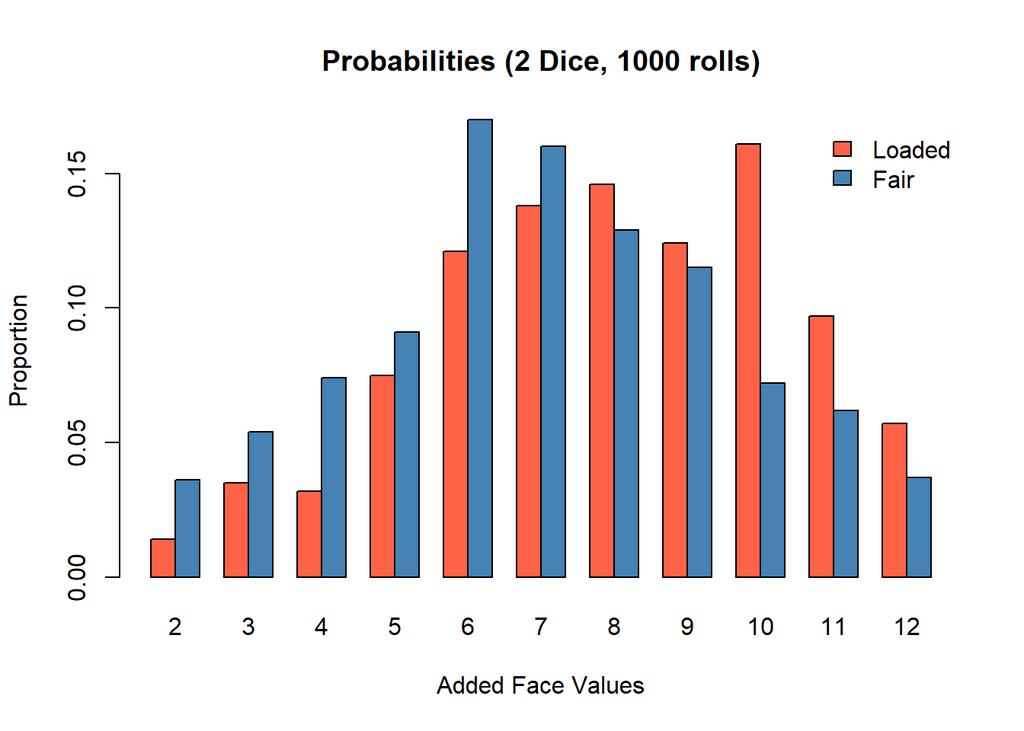

```r
# ✅  Investigate
# Side-by-side bar plot
face_props <- rbind(Bias = ploaded, Fair = pfair)
barplot(face_props,
        beside = TRUE,
        col    = c("tomato", "steelblue"),
        main   = "Probabilities (2 Dice, 1000 rolls)",
        xlab   = "Added Face Values",
        ylab   = "Proportion")
legend("topright", legend = c("Loaded", "Fair"),
       fill = c("tomato", "steelblue"), bty = "n")
```

🗣 Comment: What is the shape of the red bars compared with the blue?

# 10 📝 Practice Space

For an *BONUS* 0.5 **technical still** points, complete the practice below.

✍️ Practice: Replace the blanks (___) and run.

🧙‍♂️🗡️📜 Your friend shows up to your DnD game with a big 3D printed 20-sided die and claims it is fair. You decide to test it. [How to Make Fair DnD Dice from ANY Shape](https://www.youtube.com/watch?v=-gp7AbYD9NI)

🎯 The GOAL: Simulate 300 rolls of a loaded or fair 20‑sided die (values `1:20`) and store in **`big_die`**

```r
big_die <- sample(___ , size = ___ , replace = ___, prob = ___)

# Using `any()`, did you roll a 20?
any(big_die == ___)
```

# 11 ➤ Assignment

Replace each ____ placeholder (and any TODO comments) with working code or a short written answer. Run each section; be sure the requested objects appear in the Environment. Use the template 🎯 Goal → ⚡ Code → ✅ Checks → 🗣 Explain.

When finished, save **BOTH** you R code script file and your .RData workspace and upload to Canvas.

## 11.1 Task 1

D20 marathon

Simulate 5221 rolls of a fair 20-sided die. Store as **`boring_weekend`** using `sample()`.

```r
____ <- _____
```

## 11.2 Task 2

✅ Quick frequency check

Create **`d20_counts`**: a table of how many times each face appeared.

```r
____ <- _____
```

```r
# Quick check
print(d20_counts)
```

## 11.3 Task 3

Hit rate

What proportion of rolls were natural 20s? (one line of code, no object)

```r
____
```

## 11.4 Task 4

Baby-blanket test

Simulate 100 newborn lengths (inches) with mean 20.0, SD 0.9. Store as **`blanketed_babies`**. Use `rnorm()`.

```r
____ <- _____
```

## 11.5 Task 5

Too long?

Using `any()`, were ANY `babies > 23` in? Also count how many. No object.

```r
____(____)

____(____)
```

🗣 Comment TODO: Write Yes / No – does the hospital need longer blankets?

🗣 Comment: “___”

## 11.6 Task 6

⚠️ Week-to-week risk

Repeat Task 4 & 5 for 1000 simulated weeks. Store a vector **`weeks_too_long`** that records, for each week, the number of babies over 23 inches. Hint: `replicate()`.

```r
____ <- _____
```

## 11.7 Task 7

🤔 Reflect

📝 Write a short paragraph reflecting on what the utility of `replicate()` was in task 6?

✍️ EXPLANATION: “___”

# 12 Save and Upload

1. You will be submitting **both** the *Your Pick* Document and the workspace file. The workspace file saves all the objects in your environment that you created in this lesson. You can save the workspace by running the following command in a code chunk of the Quarto Document document:

```r
save.image("Assignment12_Workspace.RData")
```

Or you can click the “Save Workspace” button in the Environment pane.

💾 **Always save the R documents before closing.**

2. Find the assignment in this week’s module in Canvas and upload **both** the RMD and the workspace file.

# 13 Today you practiced:

- Used `sample()` for discrete simulations with or without replacement.
- Visualized uniform and aggregated dice results with histograms.
- Generated normal random numbers with `rnorm()` and plotted the shape.
- Repeated an experiment easily with `replicate()`.
- Compared two simulated distributions to spot bias.